# Development Environment Testing

### 9.2 Create virtual environment

> To create a new virtual environment, from the Command Palette (*Ctrl* + *Shift* + *P*) start typing “Python: Create Environment” and select *Python: Create Environment…*:

**Testing:**

1. Positron
2. Python
3. Venv
4. Python package installation

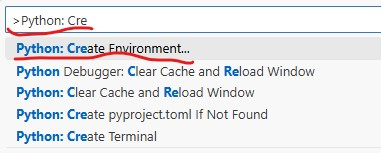

> Select *venv* as the environment type:

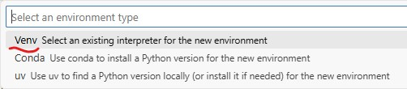

> Select a Python interpreter:

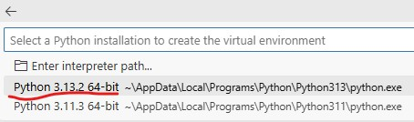

> Select the dependencies (Python packages) to install by checking `requirements.txt` file tick box:

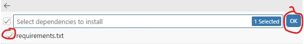

> Wait while the environment is created:

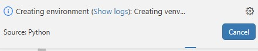

> Once it’s done you should get a notification and you should also see that *venv* is mentioned in the current interpreter selection:

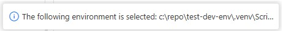

[figure not shown]

### 9.3 Render Quarto document

**Testing:**

1. Positron
2. Python
3. Python packages
4. Quarto

[figure not shown]

> From the Command Palette select *Quarto: Render Document*:

> Select *Render HTML*:

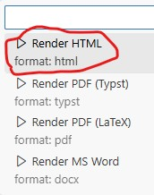

> The terminal pane will detail progress:

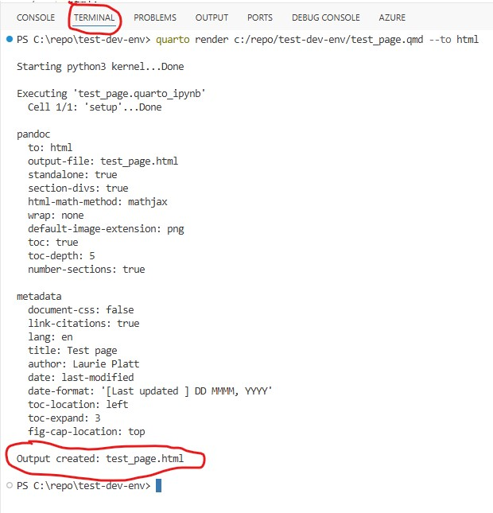

> The Positron default is for the HTML output to be shown in a preview pane. Alternatively, you can check the output by opening the `test_page.html` in your browser.